# ESM 206 Lab 5

Peter Omasta

10/29/2019

We started by forking data from github to this computer. This lab will be looking at data collected from the Santa Barbara Channel LTER, looking at Lobster populations.

Get in the habit of working by myself to pull frequently.

#### Lab 5 Objectives

- Learn to parse dates with ‘lubridate’
- Get Count of observations with count()
- Uncount() rows
- One and two-sample t-test
- Create a heat map with geom_tile()

Note that the na values are stored as -99999, but we want R to understand that is a missing value. Also don’t want to type in caps all day, so we will use janitor::clean_names(). ALSO, Date is stored as a character variable, we will need to update this as well.

Data is also not in tidy format, each observation needs to have its own row, and with the LOBSTER_COUNT column, some of the data is hidden by the counts. IE, “x count” should have x number of rows. We will use tidyr::uncount() function to convert lobster data from frequency format to case format.

```r
lobster_tidy <- lobster_abundance %>%
  tidyr::uncount(lobster_count) #what this does, it takes whatever the value is in that colun, and it repeats that row that number of times, and then deletes the column
```

#### Exploratory data vizualization

We are only going to consider ‘site’ as out variable of interest

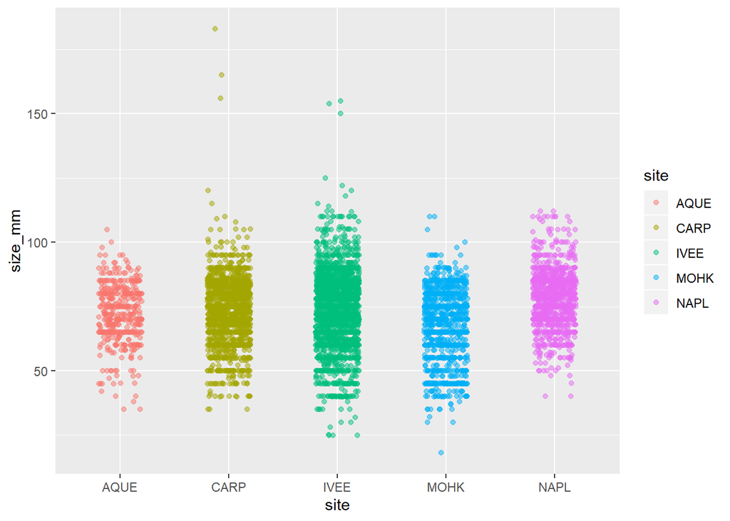

```r
ggplot(data = lobster_tidy, aes(x=site, y=size_mm)) +
  geom_jitter(aes(color=site),
              alpha = 0.5,
              width = 0.2)
```

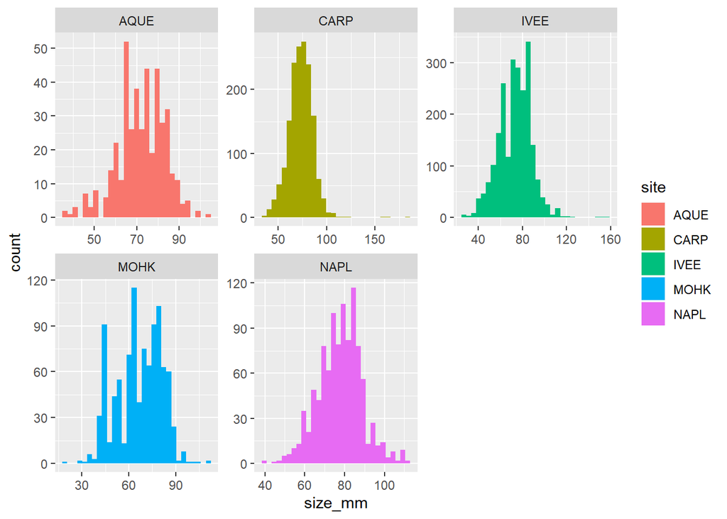

```r
# Histogram for each different site

ggplot(data = lobster_tidy, aes(x=size_mm)) +
  geom_histogram(aes(fill = site)) +
  facet_wrap(~site, scales = "free")
```

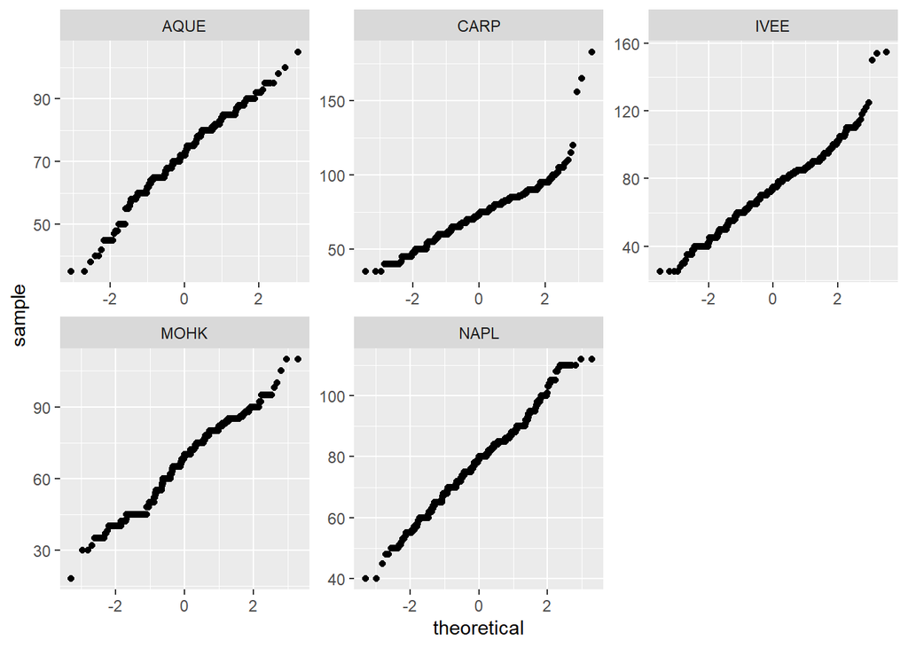

```r
#Now time for the qqplot

#Need to give a sample to compare to normal dist in aes for a qq plot
ggplot(lobster_tidy, aes(sample = size_mm)) +
  geom_qq() +
  facet_wrap(~site, scale="free")
```

```r
#Overall, this looks like a fairly linear relationship across all sites. Do not let a few outliers decide that we can no longer use a normal distribution, because they do not carry much weight vs hundreds/thousands of different points.

#Sample size of 30+ due to CLT means should be normally distributed regardless.
```

#### Convert the date column to class ‘Date’ then we will use parsed pieces to make actual counts.

We will sue the ‘lubridate’ package to convert to Date format, and then to help us easily parse month and year.

```r
lobster_date <- lobster_tidy %>%
  mutate(#Telling R what the new date format is, existing strucute is mm/dd/yyyy
    date_new = lubridate::mdy(date)
    ) %>%
  select(-date)
```

Now lets parse yar and month using lubridate::month() and lubridate::year()

```r
#Gonna add new column for just month and just year, keeping new date
#Could have piped into this but making new because YOCO

lob_parse_date <- lobster_date %>%
  mutate(
    obs_month = lubridate::month(date_new,
                                 label = TRUE),
    obs_year = lubridate::year(date_new)
  )
```

Now lets find counts of lobsters based on different hierarchical groupings. We will use dplyr::count()

First, lets count lobsters by year and month

```r
lobster_ym <- lob_parse_date %>%
  count(obs_year, obs_month)

lobster_y <- lob_parse_date %>%
  count(obs_year)

lob_site <- lob_parse_date %>%
  count(site)
```

Ifwe want to create a summary table that contains statistics OTHER than counts by group, its easier to use group_by() + n()

```r
lobs_summary <- lob_parse_date %>%
  group_by(site) %>%
  summarize(
    lobster_number = n(),
    mean_size = mean(size_mm, na.rm = TRUE),
    sd_size = sd(size_mm, na.rm = TRUE)
  )

lobs_summary
```

```
## # A tibble: 5 x 4
##   site  lobster_number mean_size sd_size
##   <chr>          <int>     <dbl>   <dbl>
## 1 AQUE             422      72.3    11.4
## 2 CARP            1619      72.8    12.5
## 3 IVEE            2304      73.6    14.4
## 4 MOHK             982      66.9    14.2
## 5 NAPL            1039      78.2    11.1
```

#### Next we will find confidence intervals (not yet discussed in lecture but you know these)

Use t.test funciton from base R to find CI intervals (for one sample_ and perform t-tests to compare means of two samples (… covered conceptually in week6 lectures))

```r
ivee_lobs <- lobster_tidy %>%
  filter(site == "IVEE") %>%
  pull(size_mm) #creates vector

# now will use t.test function to find mean of vector

t.test(ivee_lobs)
```

```
##
##  One Sample t-test
##
## data:  ivee_lobs
## t = 245.23, df = 2302, p-value < 2.2e-16
## alternative hypothesis: true mean is not equal to 0
## 95 percent confidence interval:
##  72.99130 74.16806
## sample estimates:
## mean of x
##  73.57968
```

#### Now we will do a two sample t-test to compare means

Null hypothesis always assumes that there is no relation / no effect

We want to ask is there a signifciant difference in lobster length at Naples and Mohawrk reefs?

We’ve done out necessary exploratory analyses to determine that in a 2-sample t-test means is an appropriate comparrison.

```r
naple_sample <- lobster_tidy %>%
  filter(site == "NAPL") %>%
  pull(size_mm)


mohk_sample <- lobster_tidy %>%
  filter(site=="MOHK") %>%
  pull(size_mm)

#t-test needs full vector to do a proper t.test.

mn_ttest <- t.test(mohk_sample, naple_sample)

#some values may be negative, because of order of table. statistical value does not make a difference
mn_ttest
```

```
##
##  Welch Two Sample t-test
##
## data:  mohk_sample and naple_sample
## t = -19.849, df = 1850.8, p-value < 2.2e-16
## alternative hypothesis: true difference in means is not equal to 0
## 95 percent confidence interval:
##  -12.43436 -10.19806
## sample estimates:
## mean of x mean of y
##  66.86833  78.18454
```

```r
lobster_mn <- lobster_tidy %>%
  filter(site == c("NAPL","MOHK"))

mn_ttest2 <- t.test(size_mm ~ site, data = lobster_mn)

mn_ttest
```

```
##
##  Welch Two Sample t-test
##
## data:  mohk_sample and naple_sample
## t = -19.849, df = 1850.8, p-value < 2.2e-16
## alternative hypothesis: true difference in means is not equal to 0
## 95 percent confidence interval:
##  -12.43436 -10.19806
## sample estimates:
## mean of x mean of y
##  66.86833  78.18454
```